# Analyzing Heat and Humidity at LA International Airport

Makaylah Cowan

5/1/2020

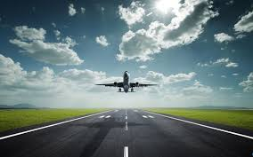

# Introduction

Relative humidity is the percentage of water vapor in the air. For reference, really saturated air that cannot hold any more water would have a relative humidity of 100%. If air’s temperature increases then it is able to hold more water molecules and the relative humidity decreases. Conversely, if air temperature decreases then the air can hold less molecules and relative humidity increases, thus air temperature and humidity are directly related. Keeping this in mind, when thinking of the most ideal flying conditions, typically we think of a bright, sunny, no-wind day, and while this can be the case, it ignores a hidden problem that can arise from these same conditions. Along with sunny days, summer brings heat and humidity which has the potential to cause serious issues with aircraft performance. These issues, called ‘density altitude’, stems from aerodynamics; humidity and hot air can cause the air to be less dense which makes it harder to sustain flight.

In this report, I will check assumptions, look at the relationship between temperature and humdiity, and analyze how the variables have changed individually at Los Angeles international airport across the years in order to see if there are more instances of high heat, humid days.

# Methods

### Data

This report was created based on a compilation of data hosted by the National Oceanic and Atmospheric Administration (NOAA). It features hourly meteorological data from LOS ANGELES INTERNATIONAL AIRPORT (LAX), with variables including temperature (Celsius), relative humidity, quantity of time for which precipitation was measured, volume of precipitation, and whether the depth was a trace amount. Additional documentation can be found in this NOAA [PDF](https://www1.ncdc.noaa.gov/pub/data/ish/ish-format-document.pdf) under ‘Precipitation Data’. Along with missing values, values for 1972 and 2020 were removed because they did not have complete, annual observations.

### Software

All analysis were done in R using dplyr, plyr, ggplot2, lubridate, and lattice packages.

### Assumptions

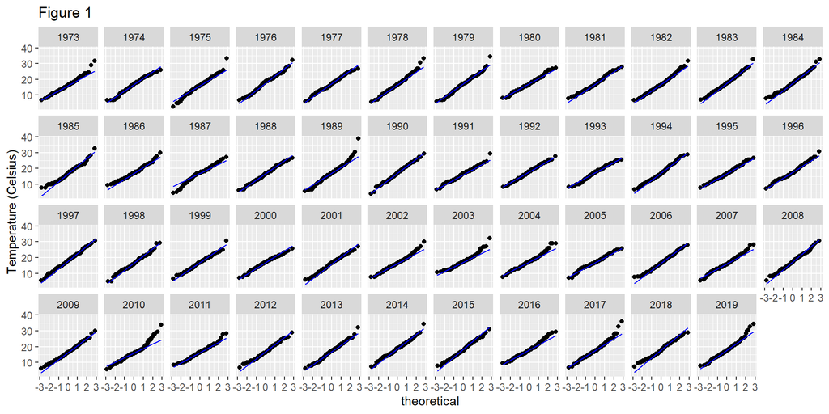

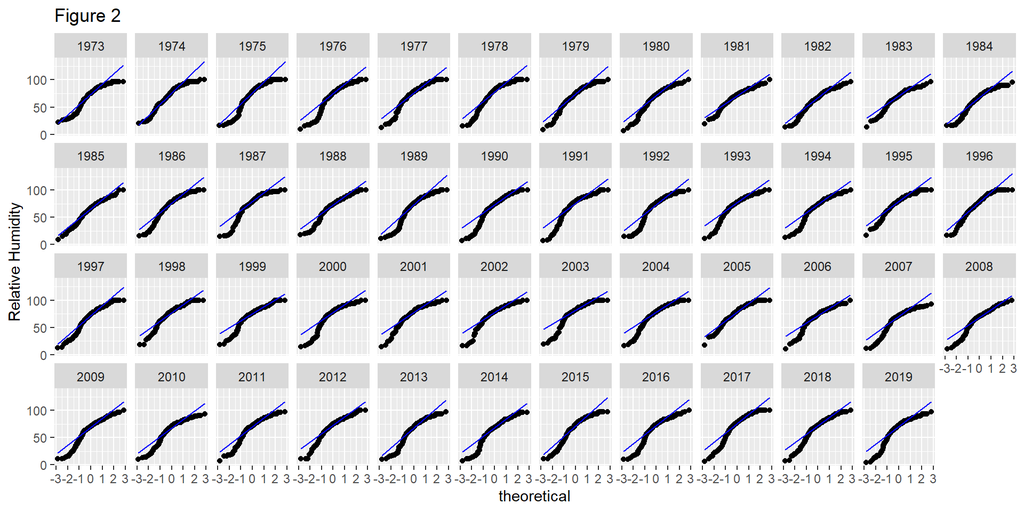

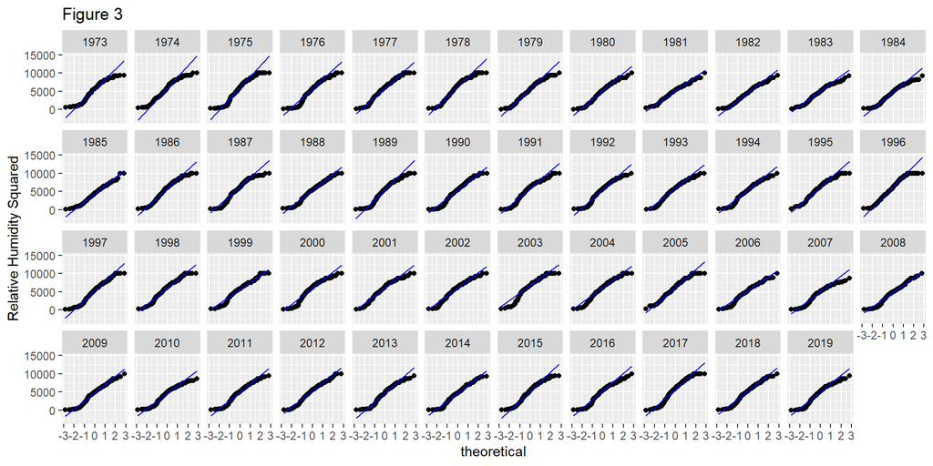

For the use of anova tests, the temperature and relative humidity variables must have sample independence, normality, and equality of variances. The sample independence requirement is met based on the experimental setup. Figure 1, a theoretical quantile-quantile plot, shows that temperature data appears to generally follow the distribution line, suggesting normality. The years 1978, 1981, 1989, 2005, 2010, and 2017 have some endpoints straying from the line, but this should not dramatically affect the results.

Plot 2 shows that the humidity data has extreme division from the line, and the shape of the endpoints suggests left skewed data; this meaning that the median value is greater than the mean value. To satisfy the normality requirement of later tests, the relative humdity data will be expressed by being squared as in Plot 3.

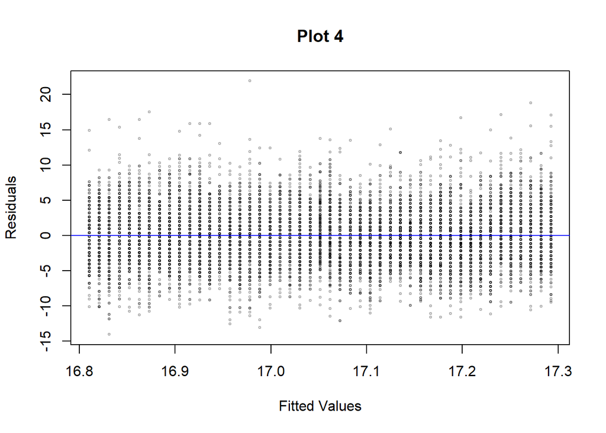

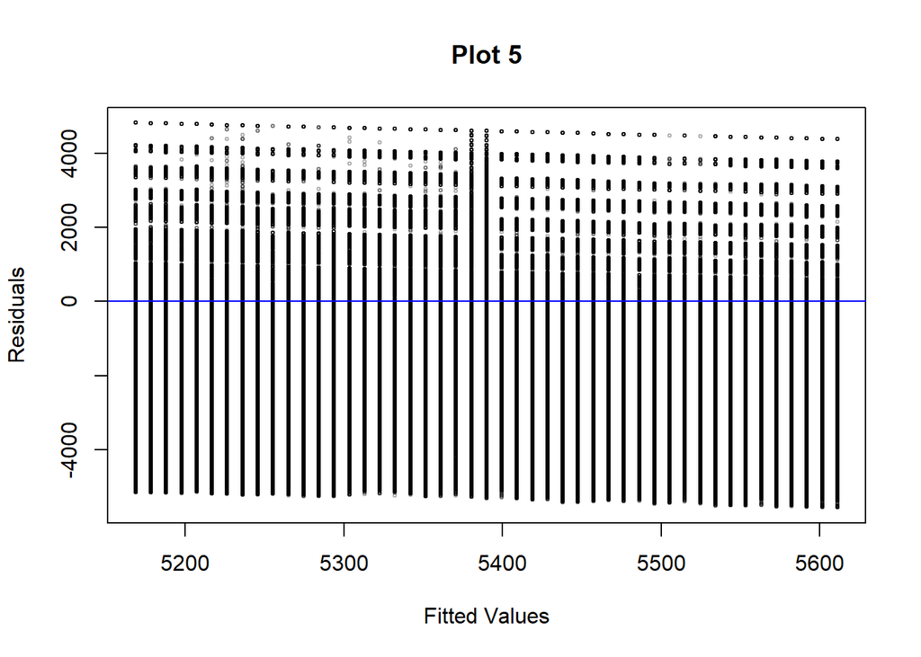

Plots 4 and 5 show that there is no apparent trend or pattern in the fitted values vs. residuals for neither the temperature nor the relative humdity data. This suggests that there is homogeneity in variance for each variable.

# Results

### Relationship - Temperature and Humidity

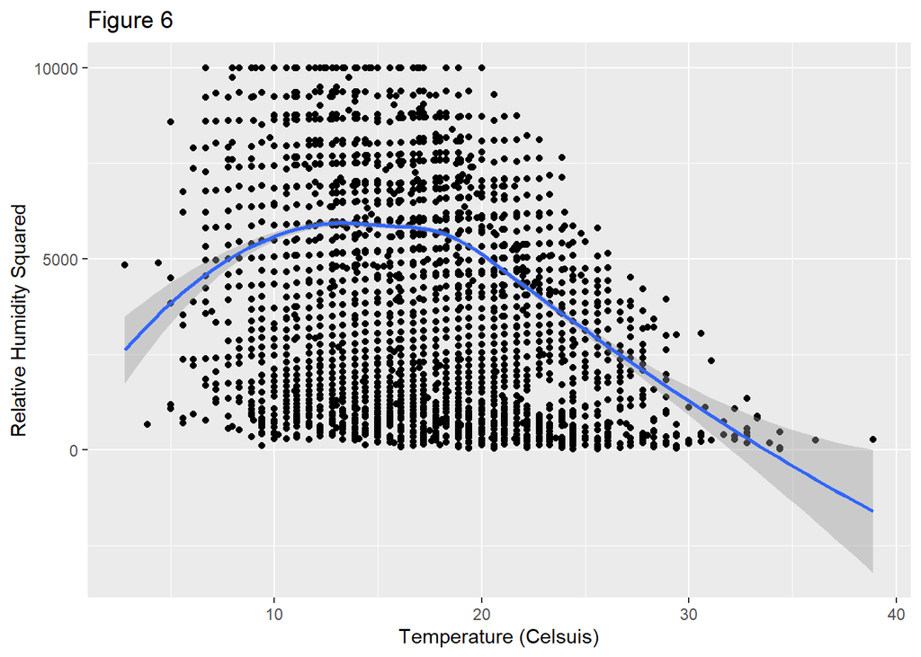

As expected, the relationship between temperature and humidity is negative. After a certain temperature, according to our data at 15 degrees celsuis, as temperature increases humidity decreases. Density altitude could occur at the points above the loess fit line where the temperature and humidity are both high.

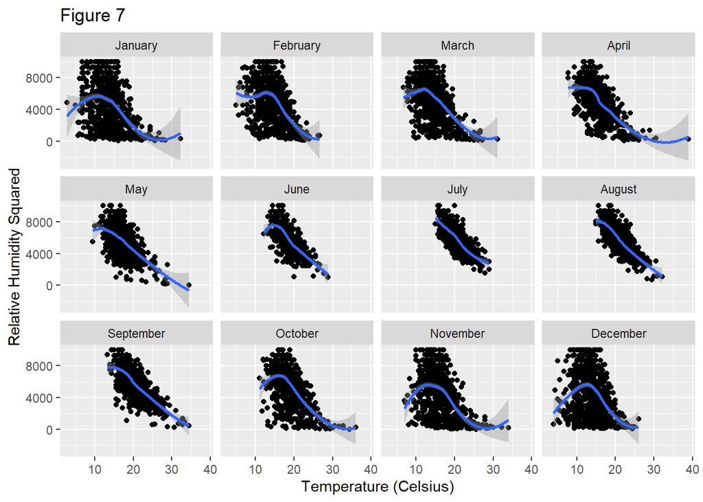

The same data except faceted by month shows us which months are most “at risk” for high temperatures and high humidity at LAX. Relative to their number of samples, July, August, and September are the most at risk months because of their temperature values and the number of points above the loess fit line.

### Temperature

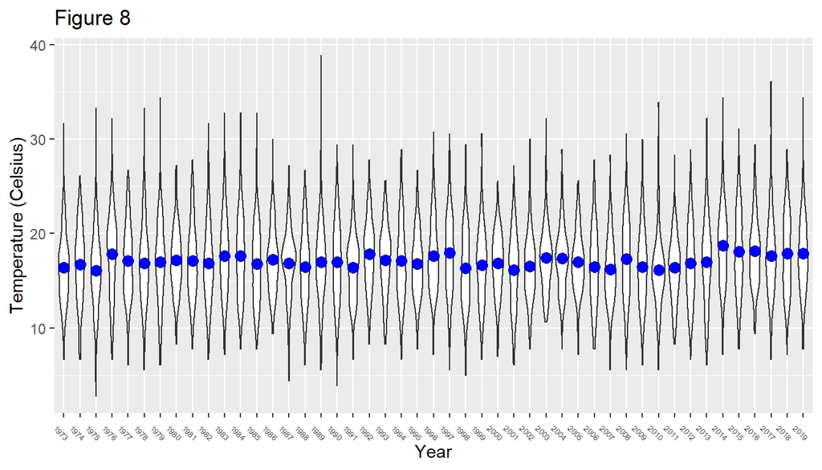

Figure 8 shows temperature as a function of time in years. The blue point represents the average temperature for the each year. On first appearances there does not appear to be significant difference between the groups. There does appear to be a slight upward trend; this will be checked by looking at a residual fit plot to determine if variance is caused by random chance.

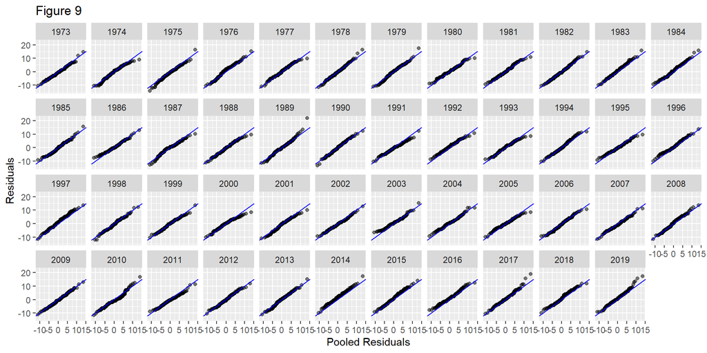

The pooled residual plot shows that the batches essentially have the same spread, so it is appropriate to do a residual fit plot.

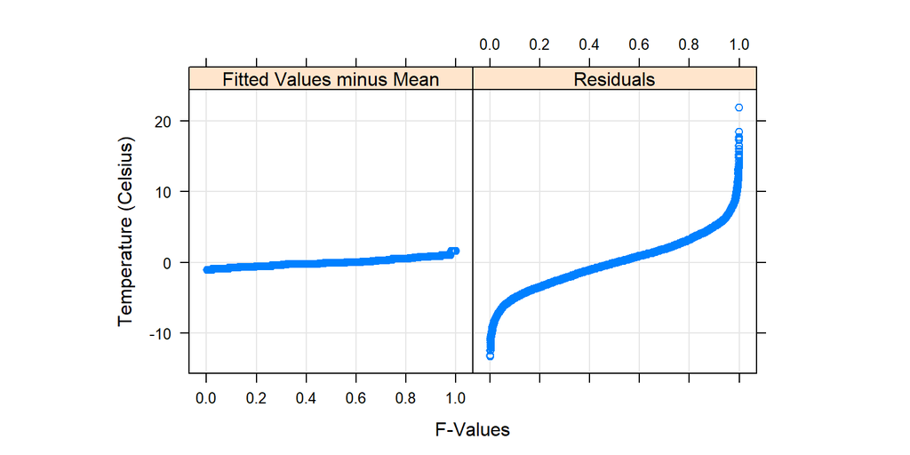

Figure 10 shows the temperature data normalized to the global mean against the residuals, with generated f-values. It reveals that the spread of the fitted teperatures across each year is insignificant compared to the spread of the residuals, so temperature differences could be explained by random chance. An Anova test will reveal if any years that are statistically different.

```
## Analysis of Variance Table
##
## Response: temp
##               Df  Sum Sq Mean Sq F value    Pr(>F)
## year           1   17389 17389.4  1058.3 < 2.2e-16 ***
## Residuals 409256 6724591    16.4
## ---
## Signif. codes:  0 '***' 0.001 '**' 0.01 '*' 0.05 '.' 0.1 ' ' 1
```

With α = .05, a p-value of 2.2 x 10<sup>-16</sup> means that we can reject the null hypothesis and can conclude that some of the temperature means do differ statistically across the years.

### Humidity

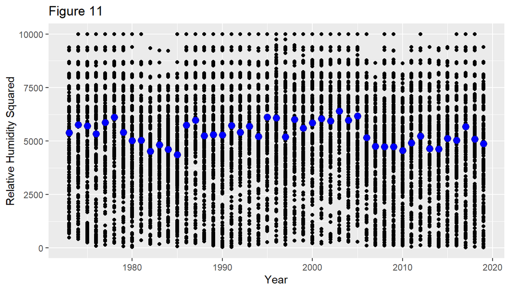

Unlike with temperature, relative humidity does not appear to have a consistent trend; the mean temperature in blue varies wildly but appears to be decreasing overall. The plot also seems to suggest breakpoints in the data which may reflect synoptic multi-year changes in weather patterns or changes in instrumentation and reporting method.

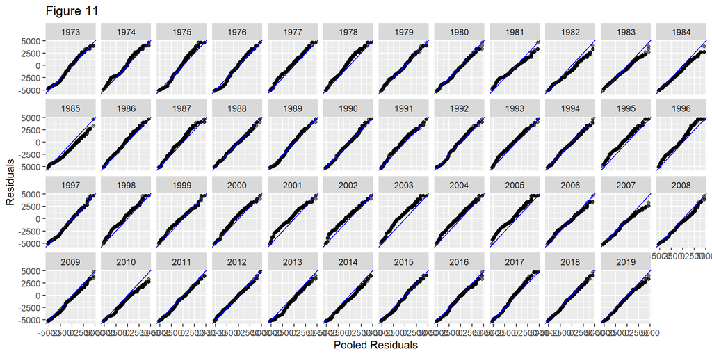

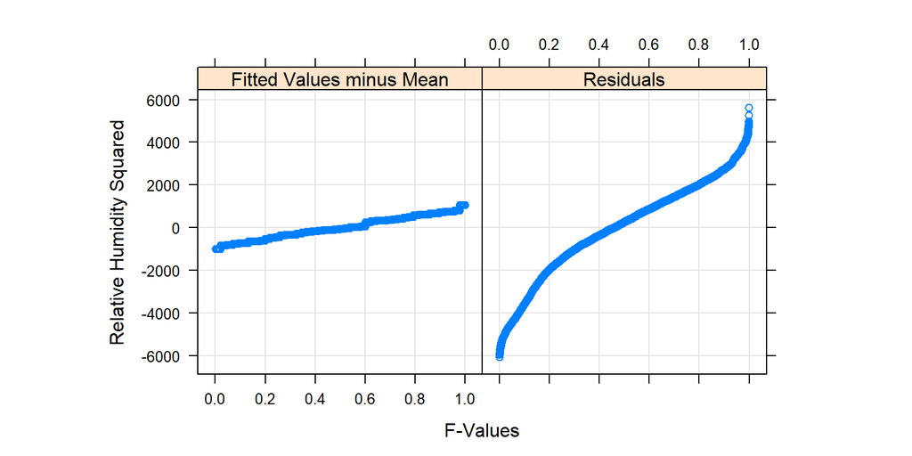

Figure 11 shows that the spreads between matches are consistent enough to be able to do a residual fit plot. Subsequently, figure 12 shows that relative humidity was not significant in relation to the residuals; this means that the variation between years could be explained by random chance.

```
## Analysis of Variance Table
##
## Response: rh^2
##               Df     Sum Sq    Mean Sq F value    Pr(>F)
## year           1 6.9852e+09 6985186722    1267 < 2.2e-16 ***
## Residuals 409256 2.2562e+12    5512955
## ---
## Signif. codes:  0 '***' 0.001 '**' 0.01 '*' 0.05 '.' 0.1 ' ' 1
```

With α = .05, a p-value of 2.2 x 10<sup>-16</sup> means that we can reject the null hypothesis, and we can conclude that mean relative humidity across the years do statistically differ from one another.

# Conclusion

Humidity and temperature are both highest in the months of July, August, and September, so these are the months to be most aware of the issue of density altitude. Across time, the trend for temperature visually appears to increase while there is not an immediately recognizable trend for humidity. However, both variables have p-values of 2.2 x 10<sup>-16</sup> which means that they have both changed signficantly across the years. Increased awareness is needed for this issue, especially in the identified months, as these variables continue to change.

# References

1. Dotson, Dianne J. “How Temperature & Humidity Are Related.” Sciencing, 23 April. 2018, sciencing.com/temperature-ampamp-humidity-related-7245642.html
2. Gimond, Manuel. Exploratory Data Analysis in R. http://mgimond.github.io/ES218/index.html
3. “Three Hs of Aircraft Performance - Hot, High and Humid.” Desert Jet, 23 Aug. 2011, www.desertjet.com/2011/08/23/aircraft-performance/
4. R Core Team (2019). R: A language and environment for statistical computing. R Foundation for Statistical Computing, Vienna, Austria. URL https://www.R-project.org/.